# Predictive Analytics - Discussion 3

Eric Kenney

2023-07-19

```r
# Required Libraries
library(fpp2)
library(fpp3)
library(rstudioapi)

path = dirname(documentPath())
```

## Import Data and Build Initial Plots

Our data set is the Monthly Air Travel data from data.world (https://data.world/makeovermonday/2021w16). I filter the data down to only travel within the United States, group by year and month, then sum up the number of passengers each month. After converting to a tsibble the data is down to 250 observations over the past 20 years.

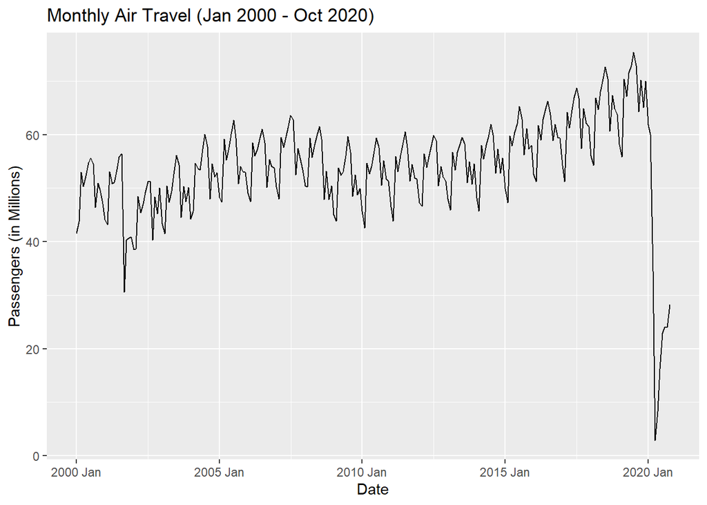

```r
air_travel = read.csv(file.path(path, "monthly_air_pax.csv"))

# Filter down to US <--> US travel only and sum monthly passengers
air_travel = air_travel %>%
  filter(ORIGIN_COUNTRY == "US" & DEST_COUNTRY == "US") %>%
  select(Sum_PASSENGERS, YEAR, MONTH) %>%
  group_by(YEAR, MONTH) %>%
  summarise(pax = sum(Sum_PASSENGERS)) %>%
  mutate(date = ym(paste(YEAR, MONTH, sep = "-"))) %>%
  mutate(date = yearmonth(date)) %>%
  ungroup() %>%
  select(pax, date) %>%
  as_tsibble(index = date)

# Plot
air_travel %>%
  autoplot(pax/1000000) +
  labs(x = "Date", y = "Passengers (in Millions)",
       title = "Monthly Air Travel (Jan 2000 - Oct 2020)")
```

As we see from the plot there is an extreme drop off at the beginning of 2020 due to the beginning of the COVID-19 Pandemic. Since it is an unreasonable expectation for any model to predict a global pandemic, I am going to remove the last 10 months of the data. This will reduce the final data set to 240 months of observations. From there I will split off a test set of 6 months.

```r
# filter out 2020
air_travel = air_travel %>%
  filter(as.Date(date) < "2020-01-01")

# Uncomment if you pulled from Github
#air_travel = read.csv(file.path(path, "air_travel_final.csv")) %>%
#  mutate(date = yearmonth(date)) %>%
#  as_tsibble(index = date)

total_obs = dim(air_travel)[1]
test_obs = 6
train_obs = total_obs - test_obs

# Build training and test sets
air_travel_train = head(air_travel, train_obs)
air_travel_test = tail(air_travel, test_obs)
```

## Models

We will build 2 models. Let’s start with an ETS model. I will allow R to pick which model works best based on AIC.

```r
ets_auto = air_travel_train %>%
  model(ETS(pax))

report(ets_auto)
```

```
## Series: pax
## Model: ETS(A,N,A)
##   Smoothing parameters:
##     alpha = 0.5310194
##     gamma = 0.0001000446
##
##   Initial states:
##      l[0]     s[0]    s[-1]  s[-2]    s[-3]   s[-4]   s[-5]   s[-6]   s[-7]
##  50347503 -1633592 -2173387 589442 -4561318 4897352 6763676 4668669 2429694
##     s[-8]   s[-9]   s[-10]   s[-11]
##  369000.8 2956393 -7884612 -6421319
##
##   sigma^2:  2.590004e+12
##
##      AIC     AICc      BIC
## 7980.456 7982.658 8032.286
```

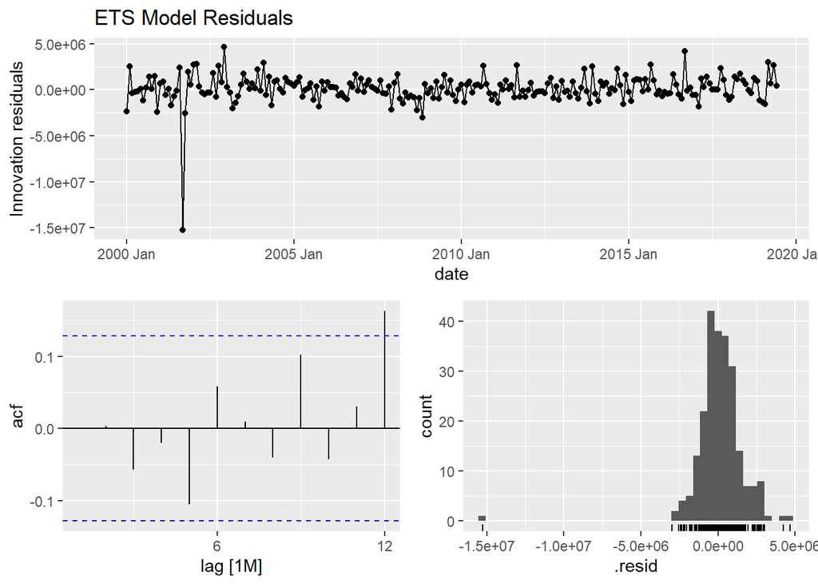

```r
ets_auto %>%
  gg_tsresiduals(lag_max = 12) +
  labs(title = "ETS Model Residuals")
```

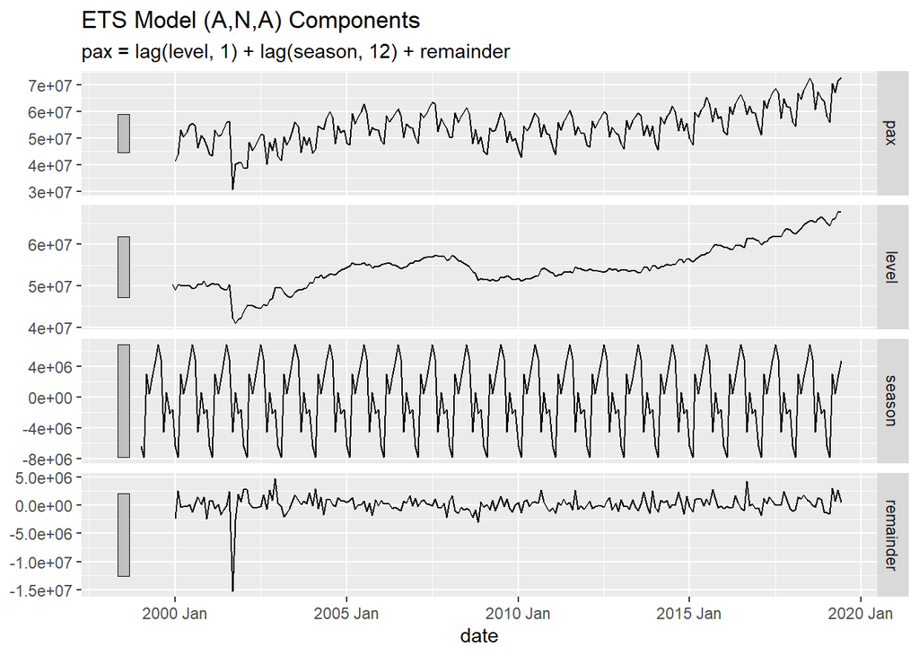

```r
components(ets_auto) %>%
  autoplot() +
  labs(title = "ETS Model (A,N,A) Components")
```

ETS picks an A,N,A model, illustrating the importance of the seasonal effect over the trend. The error remains constant with the exception of an outlier, attributed to the exceptional drop in air travel after the terrorist attack on September 11th, 2001. Next, we will create the ARIMA model for this data.

```r
arima_auto = auto.arima(air_travel_train)

arima_auto
```

```
## Series: air_travel_train
## ARIMA(1,1,2)(2,1,2)[12]
##
## Coefficients:
##           ar1     ma1     ma2    sar1     sar2     sma1    sma2
##       -0.5496  0.0971  -0.227  0.7629  -0.2067  -1.5943  0.7839
## s.e.   1.0278  1.0236   0.447  0.1651   0.1254   0.1827  0.1533
##
## sigma^2 = 2.448e+12:  log likelihood = -3471.18
## AIC=6958.37   AICc=6959.04   BIC=6985.55
```

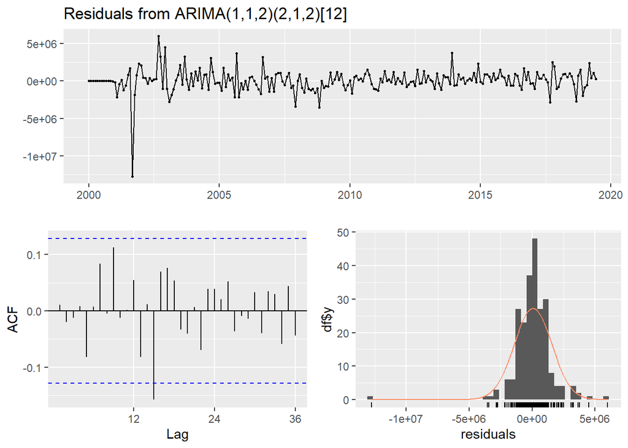

```
##
##  Ljung-Box test
##
## data:  Residuals from ARIMA(1,1,2)(2,1,2)[12]
## Q* = 21.597, df = 17, p-value = 0.2007
##
## Model df: 7.   Total lags used: 24
```

```r
checkresiduals(arima_auto)
```

Similar to the ETS model we find consistent residuals except for the same outlier. We find that the AIC for the ARIMA model is actually smaller, indicating a better fit. This won’t necessarily lead to better predictions. Let’s see how the two models do against the test set.

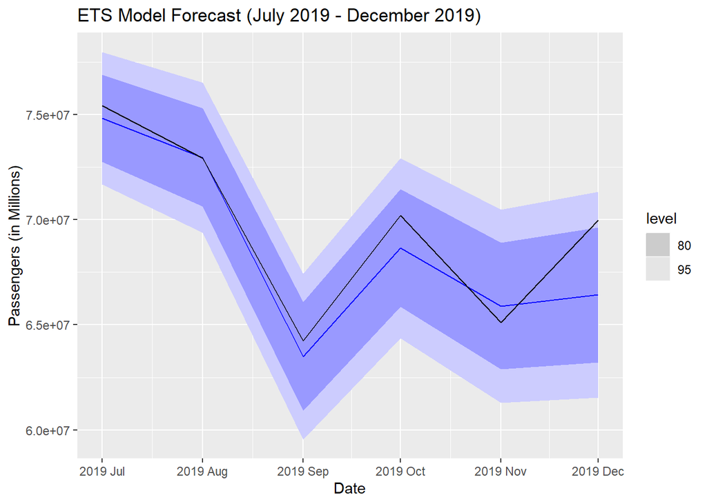

```r
# Make forecasts
ets_forecast = ets_auto %>%
  forecast(h = 6)
arima_forecast = arima_auto %>%
  forecast(h = 6)

# Plot
ets_forecast %>%
  autoplot(air_travel_test) +
  labs(x = "Date", y = "Passengers (in Millions)",
       title = "ETS Model Forecast (July 2019 - December 2019)")
```

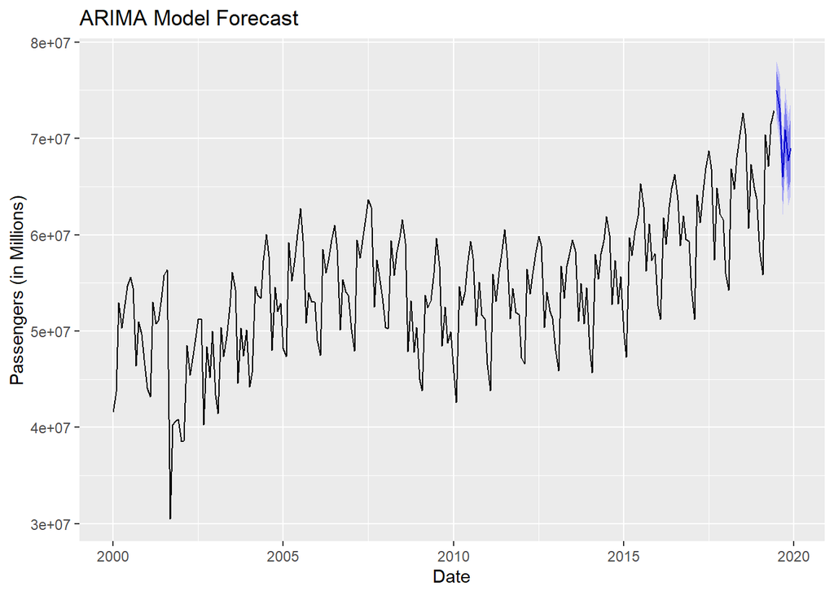

```r
arima_forecast %>%
  autoplot() +
  labs(x = "Date", y = "Passengers (in Millions)",
       title = "ARIMA Model Forecast")
```

```r
# Check accuracy
accuracy(ets_forecast, air_travel_test)
```

```
## # A tibble: 1 × 10
##   .model   .type      ME     RMSE      MAE   MPE  MAPE  MASE RMSSE   ACF1
##   <chr>    <chr>   <dbl>    <dbl>    <dbl> <dbl> <dbl> <dbl> <dbl>  <dbl>
## 1 ETS(pax) Test  939050. 1657875. 1210509.  1.33  1.75   NaN   NaN -0.457
```

```r
# Manually calculate accuracy for ARIMA
arima_errors = arima_forecast$mean - air_travel_test$pax
cat("ME:", mean(arima_errors), "\n")
```

```
## ME: 647494.2
```

```r
cat("RMSE:", sqrt(mean(arima_errors^2)), "\n")
```

```
## RMSE: 1387059
```

```r
cat("MAE:", mean(abs(arima_errors)), "\n")
```

```
## MAE: 1142614
```

```r
cat("MAPE:", mean(abs(arima_errors / air_travel_test$pax)) * 100, "\n")
```

```
## MAPE: 1.704013
```

We see from the accuracy measures that the ARIMA model performs better on the 6 month prediction than the ETS model.